# Project: Investigate a Dataset TMDb movie data

## Introduction

> This data set contains information about 10,000 movies collected from The Movie Database (TMDb), including user ratings and revenue. ● Certain columns, like ‘cast’ and ‘genres’, contain multiple values separated by pipe (|) characters. ● There are some odd characters in the ‘cast’ column. Don’t worry about cleaning them. You can leave them as is. ● The final two columns ending with “_adj” show the budget and revenue of the associated movie in terms of 2010 dollars, accounting for inflation over time
1. Which movie has the highest revenue?
2. Which movie has a the lowest revenue?
3. Look at which genre gave the most revenue?
4. Which Genre is the most Popular?
5. What is the relationship between budget and revenue?
6. What is the relationship between popularity and runtime?
7. Does a larger budget lead to larger revenues?
8. What is the relationshp between votes and popularity?
9. What is the relationship between budget and runtime?
10. Do all movies make profits?
11. Which genre is the most common?
12. Which Director has directed the most movies in the list?
13. Which director has the highest earning movies?
14. Which production company produced the most movies?
15. Which production company had the highest revenue?

```python
import pandas as pd
import numpy as np
import matplotlib.pyplot as plt
import seaborn as sns
%matplotlib inline
```

## Data Wrangling

### General Properties

```python
df_movies=pd.read_csv("tmdb-movies.csv")
```

```python
df_movies.head()
```

|  | id | imdb_id | popularity | budget | revenue | original_title | cast | homepage | director | tagline | ... | overview | runtime | genres | production_companies | release_date | vote_count | vote_average | release_year | budget_adj | revenue_adj |
| --- | --- | --- | --- | --- | --- | --- | --- | --- | --- | --- | --- | --- | --- | --- | --- | --- | --- | --- | --- | --- | --- |
| 0 | 135397 | tt0369610 | 32.985763 | 150000000 | 1513528810 | Jurassic World | Chris Pratt\|Bryce Dallas Howard\|Irrfan Khan\|Vi... | http://www.jurassicworld.com/ | Colin Trevorrow | The park is open. | ... | Twenty-two years after the events of Jurassic ... | 124 | Action\|Adventure\|Science Fiction\|Thriller | Universal Studios\|Amblin Entertainment\|Legenda... | 6/9/2015 | 5562 | 6.5 | 2015 | 137999939.3 | 1.392446e+09 |
| 1 | 76341 | tt1392190 | 28.419936 | 150000000 | 378436354 | Mad Max: Fury Road | Tom Hardy\|Charlize Theron\|Hugh Keays-Byrne\|Nic... | http://www.madmaxmovie.com/ | George Miller | What a Lovely Day. | ... | An apocalyptic story set in the furthest reach... | 120 | Action\|Adventure\|Science Fiction\|Thriller | Village Roadshow Pictures\|Kennedy Miller Produ... | 5/13/2015 | 6185 | 7.1 | 2015 | 137999939.3 | 3.481613e+08 |
| 2 | 262500 | tt2908446 | 13.112507 | 110000000 | 295238201 | Insurgent | Shailene Woodley\|Theo James\|Kate Winslet\|Ansel... | http://www.thedivergentseries.movie/#insurgent | Robert Schwentke | One Choice Can Destroy You | ... | Beatrice Prior must confront her inner demons ... | 119 | Adventure\|Science Fiction\|Thriller | Summit Entertainment\|Mandeville Films\|Red Wago... | 3/18/2015 | 2480 | 6.3 | 2015 | 101199955.5 | 2.716190e+08 |
| 3 | 140607 | tt2488496 | 11.173104 | 200000000 | 2068178225 | Star Wars: The Force Awakens | Harrison Ford\|Mark Hamill\|Carrie Fisher\|Adam D... | http://www.starwars.com/films/star-wars-episod... | J.J. Abrams | Every generation has a story. | ... | Thirty years after defeating the Galactic Empi... | 136 | Action\|Adventure\|Science Fiction\|Fantasy | Lucasfilm\|Truenorth Productions\|Bad Robot | 12/15/2015 | 5292 | 7.5 | 2015 | 183999919.0 | 1.902723e+09 |
| 4 | 168259 | tt2820852 | 9.335014 | 190000000 | 1506249360 | Furious 7 | Vin Diesel\|Paul Walker\|Jason Statham\|Michelle ... | http://www.furious7.com/ | James Wan | Vengeance Hits Home | ... | Deckard Shaw seeks revenge against Dominic Tor... | 137 | Action\|Crime\|Thriller | Universal Pictures\|Original Film\|Media Rights ... | 4/1/2015 | 2947 | 7.3 | 2015 | 174799923.1 | 1.385749e+09 |

5 rows × 21 columns

```python
df_movies.shape
```

```
(10866, 21)
```

```python
#Get more information about the dataset
df_movies.info()
```

```
<class 'pandas.core.frame.DataFrame'>
RangeIndex: 10866 entries, 0 to 10865
Data columns (total 21 columns):
 #   Column                Non-Null Count  Dtype
---  ------                --------------  -----
 0   id                    10866 non-null  int64
 1   imdb_id               10856 non-null  object
 2   popularity            10866 non-null  float64
 3   budget                10866 non-null  int64
 4   revenue               10866 non-null  int64
 5   original_title        10866 non-null  object
 6   cast                  10790 non-null  object
 7   homepage              2936 non-null   object
 8   director              10822 non-null  object
 9   tagline               8042 non-null   object
 10  keywords              9373 non-null   object
 11  overview              10862 non-null  object
 12  runtime               10866 non-null  int64
 13  genres                10843 non-null  object
 14  production_companies  9836 non-null   object
 15  release_date          10866 non-null  object
 16  vote_count            10866 non-null  int64
 17  vote_average          10866 non-null  float64
 18  release_year          10866 non-null  int64
 19  budget_adj            10866 non-null  float64
 20  revenue_adj           10866 non-null  float64
dtypes: float64(4), int64(6), object(11)
memory usage: 1.7+ MB
```

```python
df_movies.describe()
```

|  | id | popularity | budget | revenue | runtime | vote_count | vote_average | release_year | budget_adj | revenue_adj |
| --- | --- | --- | --- | --- | --- | --- | --- | --- | --- | --- |
| count | 10866.000000 | 10866.000000 | 1.086600e+04 | 1.086600e+04 | 10866.000000 | 10866.000000 | 10866.000000 | 10866.000000 | 1.086600e+04 | 1.086600e+04 |
| mean | 66064.177434 | 0.646441 | 1.462570e+07 | 3.982332e+07 | 102.070863 | 217.389748 | 5.974922 | 2001.322658 | 1.755104e+07 | 5.136436e+07 |
| std | 92130.136561 | 1.000185 | 3.091321e+07 | 1.170035e+08 | 31.381405 | 575.619058 | 0.935142 | 12.812941 | 3.430616e+07 | 1.446325e+08 |
| min | 5.000000 | 0.000065 | 0.000000e+00 | 0.000000e+00 | 0.000000 | 10.000000 | 1.500000 | 1960.000000 | 0.000000e+00 | 0.000000e+00 |
| 25% | 10596.250000 | 0.207583 | 0.000000e+00 | 0.000000e+00 | 90.000000 | 17.000000 | 5.400000 | 1995.000000 | 0.000000e+00 | 0.000000e+00 |
| 50% | 20669.000000 | 0.383856 | 0.000000e+00 | 0.000000e+00 | 99.000000 | 38.000000 | 6.000000 | 2006.000000 | 0.000000e+00 | 0.000000e+00 |
| 75% | 75610.000000 | 0.713817 | 1.500000e+07 | 2.400000e+07 | 111.000000 | 145.750000 | 6.600000 | 2011.000000 | 2.085325e+07 | 3.369710e+07 |
| max | 417859.000000 | 32.985763 | 4.250000e+08 | 2.781506e+09 | 900.000000 | 9767.000000 | 9.200000 | 2015.000000 | 4.250000e+08 | 2.827124e+09 |

```python
# looking at the data the columns with missing values are: cast,homepage, director,tagline, keywords,overviiew,
#genres and production companies.
#Replace null values with the string "Unknown"
df_movies.fillna("unknown", inplace = True)
```

```python
df_movies.head()
```

|  | id | imdb_id | popularity | budget | revenue | original_title | cast | homepage | director | tagline | ... | overview | runtime | genres | production_companies | release_date | vote_count | vote_average | release_year | budget_adj | revenue_adj |
| --- | --- | --- | --- | --- | --- | --- | --- | --- | --- | --- | --- | --- | --- | --- | --- | --- | --- | --- | --- | --- | --- |
| 0 | 135397 | tt0369610 | 32.985763 | 150000000 | 1513528810 | Jurassic World | Chris Pratt\|Bryce Dallas Howard\|Irrfan Khan\|Vi... | http://www.jurassicworld.com/ | Colin Trevorrow | The park is open. | ... | Twenty-two years after the events of Jurassic ... | 124 | Action\|Adventure\|Science Fiction\|Thriller | Universal Studios\|Amblin Entertainment\|Legenda... | 6/9/2015 | 5562 | 6.5 | 2015 | 137999939.3 | 1.392446e+09 |
| 1 | 76341 | tt1392190 | 28.419936 | 150000000 | 378436354 | Mad Max: Fury Road | Tom Hardy\|Charlize Theron\|Hugh Keays-Byrne\|Nic... | http://www.madmaxmovie.com/ | George Miller | What a Lovely Day. | ... | An apocalyptic story set in the furthest reach... | 120 | Action\|Adventure\|Science Fiction\|Thriller | Village Roadshow Pictures\|Kennedy Miller Produ... | 5/13/2015 | 6185 | 7.1 | 2015 | 137999939.3 | 3.481613e+08 |
| 2 | 262500 | tt2908446 | 13.112507 | 110000000 | 295238201 | Insurgent | Shailene Woodley\|Theo James\|Kate Winslet\|Ansel... | http://www.thedivergentseries.movie/#insurgent | Robert Schwentke | One Choice Can Destroy You | ... | Beatrice Prior must confront her inner demons ... | 119 | Adventure\|Science Fiction\|Thriller | Summit Entertainment\|Mandeville Films\|Red Wago... | 3/18/2015 | 2480 | 6.3 | 2015 | 101199955.5 | 2.716190e+08 |
| 3 | 140607 | tt2488496 | 11.173104 | 200000000 | 2068178225 | Star Wars: The Force Awakens | Harrison Ford\|Mark Hamill\|Carrie Fisher\|Adam D... | http://www.starwars.com/films/star-wars-episod... | J.J. Abrams | Every generation has a story. | ... | Thirty years after defeating the Galactic Empi... | 136 | Action\|Adventure\|Science Fiction\|Fantasy | Lucasfilm\|Truenorth Productions\|Bad Robot | 12/15/2015 | 5292 | 7.5 | 2015 | 183999919.0 | 1.902723e+09 |
| 4 | 168259 | tt2820852 | 9.335014 | 190000000 | 1506249360 | Furious 7 | Vin Diesel\|Paul Walker\|Jason Statham\|Michelle ... | http://www.furious7.com/ | James Wan | Vengeance Hits Home | ... | Deckard Shaw seeks revenge against Dominic Tor... | 137 | Action\|Crime\|Thriller | Universal Pictures\|Original Film\|Media Rights ... | 4/1/2015 | 2947 | 7.3 | 2015 | 174799923.1 | 1.385749e+09 |

5 rows × 21 columns

```python
#check if there are any duplicated rows
df_movies.duplicated().sum()
```

```
1
```

```python
#remove duplicates from dataframe
df_movies=df_movies.drop_duplicates(keep="first")
```

```python
df_movies.duplicated().sum()
```

```
0
```

```python
#remove unused columns
df_movies.drop(['imdb_id','homepage', 'tagline', 'keywords', 'overview','budget_adj','revenue_adj'], axis = 1, inplace = True)
df_movies.head()
```

|  | id | popularity | budget | revenue | original_title | cast | director | runtime | genres | production_companies | release_date | vote_count | vote_average | release_year |
| --- | --- | --- | --- | --- | --- | --- | --- | --- | --- | --- | --- | --- | --- | --- |
| 0 | 135397 | 32.985763 | 150000000 | 1513528810 | Jurassic World | Chris Pratt\|Bryce Dallas Howard\|Irrfan Khan\|Vi... | Colin Trevorrow | 124 | Action\|Adventure\|Science Fiction\|Thriller | Universal Studios\|Amblin Entertainment\|Legenda... | 6/9/2015 | 5562 | 6.5 | 2015 |
| 1 | 76341 | 28.419936 | 150000000 | 378436354 | Mad Max: Fury Road | Tom Hardy\|Charlize Theron\|Hugh Keays-Byrne\|Nic... | George Miller | 120 | Action\|Adventure\|Science Fiction\|Thriller | Village Roadshow Pictures\|Kennedy Miller Produ... | 5/13/2015 | 6185 | 7.1 | 2015 |
| 2 | 262500 | 13.112507 | 110000000 | 295238201 | Insurgent | Shailene Woodley\|Theo James\|Kate Winslet\|Ansel... | Robert Schwentke | 119 | Adventure\|Science Fiction\|Thriller | Summit Entertainment\|Mandeville Films\|Red Wago... | 3/18/2015 | 2480 | 6.3 | 2015 |
| 3 | 140607 | 11.173104 | 200000000 | 2068178225 | Star Wars: The Force Awakens | Harrison Ford\|Mark Hamill\|Carrie Fisher\|Adam D... | J.J. Abrams | 136 | Action\|Adventure\|Science Fiction\|Fantasy | Lucasfilm\|Truenorth Productions\|Bad Robot | 12/15/2015 | 5292 | 7.5 | 2015 |
| 4 | 168259 | 9.335014 | 190000000 | 1506249360 | Furious 7 | Vin Diesel\|Paul Walker\|Jason Statham\|Michelle ... | James Wan | 137 | Action\|Crime\|Thriller | Universal Pictures\|Original Film\|Media Rights ... | 4/1/2015 | 2947 | 7.3 | 2015 |

```python
#get information about the dataframe after removing duplicates from dataframe and filling Null with unknown
df_movies.info()
```

```
<class 'pandas.core.frame.DataFrame'>
Int64Index: 10865 entries, 0 to 10865
Data columns (total 14 columns):
 #   Column                Non-Null Count  Dtype
---  ------                --------------  -----
 0   id                    10865 non-null  int64
 1   popularity            10865 non-null  float64
 2   budget                10865 non-null  int64
 3   revenue               10865 non-null  int64
 4   original_title        10865 non-null  object
 5   cast                  10865 non-null  object
 6   director              10865 non-null  object
 7   runtime               10865 non-null  int64
 8   genres                10865 non-null  object
 9   production_companies  10865 non-null  object
 10  release_date          10865 non-null  object
 11  vote_count            10865 non-null  int64
 12  vote_average          10865 non-null  float64
 13  release_year          10865 non-null  int64
dtypes: float64(2), int64(6), object(6)
memory usage: 1.2+ MB
```

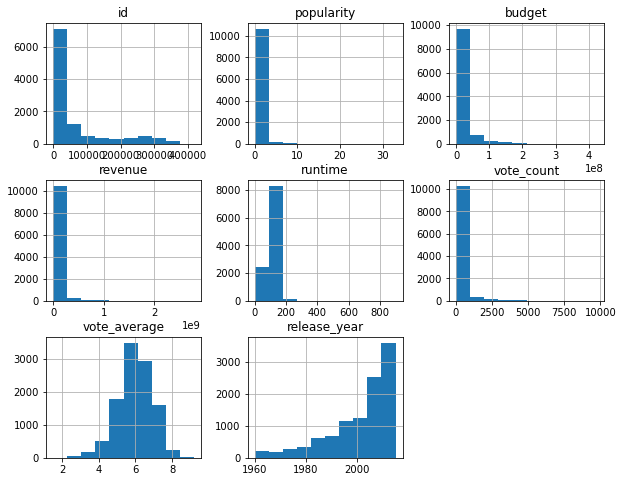

```python
df_movies.hist(figsize=(10,8));
```

##### Observation:

- We can say that the popularity is similar for most of the movies.
- We can say that the budget is similar for most of the movies.
- We can say that the revenue is similar for most of the movies.
- We can say that the vote count is similar for most of the movies
- We can say that the vote average is around 4 and 8 or most movies.
- Most movies have a runtime between 0 and 200. Most seem to be around 100 and 200.
- More movies are released as the years progress, we see a sharp increase of movies produced in the 2000s.

## Exploratory Data Analysis

```python
# To find the correlation among the columns using pearson method. This gives me a direction to go in when attempting to answer the questions
df_movies.corr(method ='pearson')
```

|  | id | popularity | budget | revenue | runtime | vote_count | vote_average | release_year |
| --- | --- | --- | --- | --- | --- | --- | --- | --- |
| id | 1.000000 | -0.014351 | -0.141341 | -0.099235 | -0.088368 | -0.035555 | -0.058391 | 0.511393 |
| popularity | -0.014351 | 1.000000 | 0.545481 | 0.663360 | 0.139032 | 0.800828 | 0.209517 | 0.089806 |
| budget | -0.141341 | 0.545481 | 1.000000 | 0.734928 | 0.191300 | 0.632719 | 0.081067 | 0.115904 |
| revenue | -0.099235 | 0.663360 | 0.734928 | 1.000000 | 0.162830 | 0.791174 | 0.172541 | 0.057070 |
| runtime | -0.088368 | 0.139032 | 0.191300 | 0.162830 | 1.000000 | 0.163273 | 0.156813 | -0.117187 |
| vote_count | -0.035555 | 0.800828 | 0.632719 | 0.791174 | 0.163273 | 1.000000 | 0.253818 | 0.107962 |
| vote_average | -0.058391 | 0.209517 | 0.081067 | 0.172541 | 0.156813 | 0.253818 | 1.000000 | -0.117576 |
| release_year | 0.511393 | 0.089806 | 0.115904 | 0.057070 | -0.117187 | 0.107962 | -0.117576 | 1.000000 |

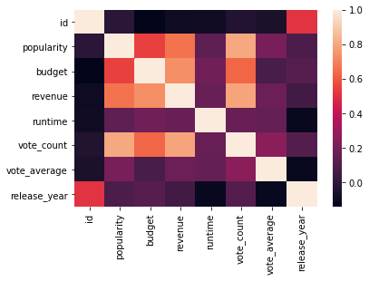

```python
#Start by looking at the relationship for all the movies
correlations=df_movies.corr(method ='pearson')
sns.heatmap(correlations)
plt.show()
```

##### Observation:

There seems to be a positive relationship between vote count and poularity and between vote count and revenue. There seems to be a positive relationship between revenue and budget. There seems to be a weak relationship between popularity and vote average, budget and vote average, runtime and popularity, runtime and budget, runtime and revenue, vote count and runtime, vote average and runtime, popularity and release year.

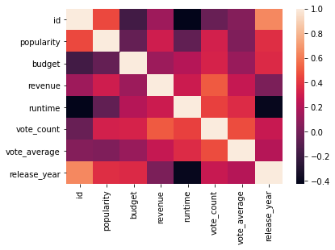

```python
#View relationship for top  100 highest revenue movies
df_movies_top_100=df_movies.sort_values("revenue",ascending=False)
df_movies_top_100=df_movies_top_100.head(20)
correlations=df_movies_top_100.corr(method ='pearson')
sns.heatmap(correlations)
plt.show()
```

##### Observation:

There seems to be a positive relationship, slightly strong between popularity and revenue, revenue and vote count, runtime and revenue, runtime and vote count.There seems to be no relationship between popularity and budget and runtime and popularity.

### 1. Which movies has the highest revenue?

```python
#sort the dataset by revenue from hihgest revenue to lowest.
df_movies_by_rev=df_movies.sort_values("revenue",ascending=False)
df_movies_by_rev.head()
```

|  | id | popularity | budget | revenue | original_title | cast | director | runtime | genres | production_companies | release_date | vote_count | vote_average | release_year |
| --- | --- | --- | --- | --- | --- | --- | --- | --- | --- | --- | --- | --- | --- | --- |
| 1386 | 19995 | 9.432768 | 237000000 | 2781505847 | Avatar | Sam Worthington\|Zoe Saldana\|Sigourney Weaver\|S... | James Cameron | 162 | Action\|Adventure\|Fantasy\|Science Fiction | Ingenious Film Partners\|Twentieth Century Fox ... | 12/10/2009 | 8458 | 7.1 | 2009 |
| 3 | 140607 | 11.173104 | 200000000 | 2068178225 | Star Wars: The Force Awakens | Harrison Ford\|Mark Hamill\|Carrie Fisher\|Adam D... | J.J. Abrams | 136 | Action\|Adventure\|Science Fiction\|Fantasy | Lucasfilm\|Truenorth Productions\|Bad Robot | 12/15/2015 | 5292 | 7.5 | 2015 |
| 5231 | 597 | 4.355219 | 200000000 | 1845034188 | Titanic | Kate Winslet\|Leonardo DiCaprio\|Frances Fisher\|... | James Cameron | 194 | Drama\|Romance\|Thriller | Paramount Pictures\|Twentieth Century Fox Film ... | 11/18/1997 | 4654 | 7.3 | 1997 |
| 4361 | 24428 | 7.637767 | 220000000 | 1519557910 | The Avengers | Robert Downey Jr.\|Chris Evans\|Mark Ruffalo\|Chr... | Joss Whedon | 143 | Science Fiction\|Action\|Adventure | Marvel Studios | 4/25/2012 | 8903 | 7.3 | 2012 |
| 0 | 135397 | 32.985763 | 150000000 | 1513528810 | Jurassic World | Chris Pratt\|Bryce Dallas Howard\|Irrfan Khan\|Vi... | Colin Trevorrow | 124 | Action\|Adventure\|Science Fiction\|Thriller | Universal Studios\|Amblin Entertainment\|Legenda... | 6/9/2015 | 5562 | 6.5 | 2015 |

### 2. Which movie has a the lowest revenue?

```python
df_movies_by_rev.tail()
```

|  | id | popularity | budget | revenue | original_title | cast | director | runtime | genres | production_companies | release_date | vote_count | vote_average | release_year |
| --- | --- | --- | --- | --- | --- | --- | --- | --- | --- | --- | --- | --- | --- | --- |
| 1164 | 244562 | 0.165741 | 0 | 0 | Jamie Marks Is Dead | Cameron Monaghan\|Noah Silver\|Morgan Saylor\|Mad... | Carter Smith | 100 | Drama\|Thriller | Verisimilitude | 8/29/2014 | 14 | 5.9 | 2014 |
| 5421 | 40413 | 0.077201 | 0 | 0 | Les Randonneurs | Philippe Harel\|Vincent Elbaz\|GÃ©raldine Pailha... | Philippe Harel | 95 | Drama\|Romance\|Foreign | unknown | 3/12/1997 | 17 | 4.9 | 1997 |
| 5419 | 44706 | 0.139139 | 0 | 0 | Le Pari | Didier Bourdon\|Bernard Campan\|Isabelle Ferron\|... | Didier Bourdon\|Bernard Campan | 100 | Comedy | Renn Productions\|TF1 Films Production | 10/15/1997 | 29 | 6.1 | 1997 |
| 5418 | 27318 | 0.041454 | 0 | 0 | Jack Frost | Scott MacDonald\|Christopher Allport\|Stephen Me... | Michael Cooney | 89 | Fantasy\|Horror\|Comedy | Moonstone Entertainment | 11/18/1997 | 15 | 6.0 | 1997 |
| 10865 | 22293 | 0.035919 | 19000 | 0 | Manos: The Hands of Fate | Harold P. Warren\|Tom Neyman\|John Reynolds\|Dian... | Harold P. Warren | 74 | Horror | Norm-Iris | 11/15/1966 | 15 | 1.5 | 1966 |

```python
df_movies_by_rev.revenue.value_counts()
```

```
0            6016
12000000       10
10000000        8
11000000        7
6000000         6
             ...
346079773       1
44456478        1
65884703        1
137783840       1
18432000        1
Name: revenue, Length: 4702, dtype: int64
```

### 3. Look at which genre combination gave the most revenue?

```python
# Use this, and more code cells, to explore your data. Don't forget to add
#   Markdown cells to document your observations and findings.
#Look at which genre gave the most revenue?
df_movies.genres.unique()
```

```
array(['Action|Adventure|Science Fiction|Thriller',
       'Adventure|Science Fiction|Thriller',
       'Action|Adventure|Science Fiction|Fantasy', ...,
       'Adventure|Drama|Action|Family|Foreign',
       'Comedy|Family|Mystery|Romance',
       'Mystery|Science Fiction|Thriller|Drama'], dtype=object)
```

```python
# Create a Container Dictionary
averages = {}

# Split the data into different regions
for genre in df_movies['genres'].unique():
    df_genres = df_movies[df_movies['genres'] == genre]

    # Apply an aggregation function
    average = df_genres['revenue'].mean()

    # Combine the data into a DataFrame
    averages[genre] = [average]

aggregate_df = pd.DataFrame.from_dict(averages, orient='index', columns=['Average_Revenue'])
aggregate_df.head()
```

|  | Average_Revenue |
| --- | --- |
| Action\|Adventure\|Science Fiction\|Thriller | 2.330352e+08 |
| Adventure\|Science Fiction\|Thriller | 2.952382e+08 |
| Action\|Adventure\|Science Fiction\|Fantasy | 1.034089e+09 |
| Action\|Crime\|Thriller | 7.518905e+07 |
| Western\|Drama\|Adventure\|Thriller | 5.329505e+08 |

```python
aggregate_df = aggregate_df[aggregate_df.Average_Revenue > 0]
aggregate_df=aggregate_df.sort_values("Average_Revenue",ascending=False)
aggregate_df=aggregate_df.head(20)
aggregate_df.head()
```

|  | Average_Revenue |
| --- | --- |
| Crime\|Drama\|Mystery\|Thriller\|Action | 1.106280e+09 |
| Action\|Adventure\|Science Fiction\|Fantasy | 1.034089e+09 |
| Family\|Fantasy\|Adventure | 1.025467e+09 |
| Adventure\|Fantasy\|Family\|Mystery | 9.382127e+08 |
| Science Fiction\|Thriller\|Action\|Adventure | 8.474235e+08 |

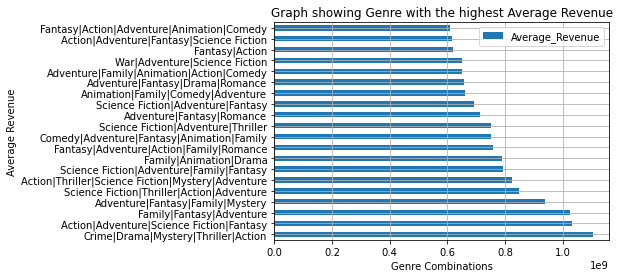

```python
aggregate_df.plot.barh()
plt.xlabel("Genre Combinations")
plt.ylabel("Average Revenue")
plt.title("Graph showing Genre with the highest Average Revenue")
plt.grid(True)
plt.show()
```

##### Observation:

The Combination of Crime|Drama|Mystery|Thriller|Action is the highest earning genre combination

### 4. Which Combination Genre is the most Popular?

```python
# 20 of Highest Revevenue films by genre
```

```python
# Apply an aggregation function
average = df_genres['popularity'].mean()

# Combine the data into a DataFrame
averages[genre] = [average]

popularity_df = pd.DataFrame.from_dict(averages, orient='index', columns=['%_Popularity'])
popularity_df.head()
```

|  | %_Popularity |
| --- | --- |
| Action\|Adventure\|Science Fiction\|Thriller | 2.330352e+08 |
| Adventure\|Science Fiction\|Thriller | 2.952382e+08 |
| Action\|Adventure\|Science Fiction\|Fantasy | 1.034089e+09 |
| Action\|Crime\|Thriller | 7.518905e+07 |
| Western\|Drama\|Adventure\|Thriller | 5.329505e+08 |

```python
popularity_df=popularity_df.sort_values('%_Popularity',ascending=False)
popularity_df=popularity_df.head(20)
```

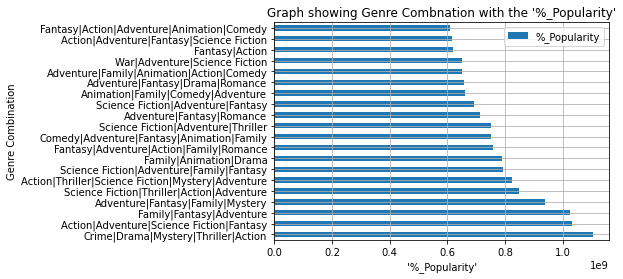

```python
popularity_df.plot.barh()
plt.xlabel("'%_Popularity'")
plt.ylabel("Genre Combination")
plt.title("Graph showing Genre Combnation with the '%_Popularity'")
plt.grid(True)
plt.show()
```

### 5. What is the relationship between budget and revenue?

```python
def scatter_chart(column1,column2,x_label,y_label,graph_heading):

    x=df_movies[column1]
    y=df_movies[column2]
    plt.scatter(x,y)
    #calculate equation for trendline
    z = np.polyfit(x, y, 1)
    p = np.poly1d(z)
    plt.xlabel(x_label)
    plt.ylabel(y_label)
    plt.title(graph_heading)
    plt.grid(True)
    #add trendline to plot
    plt.plot(x, p(x),color="red")
```

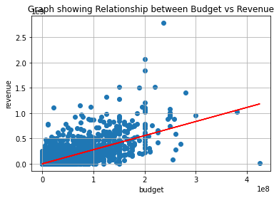

```python
scatter_chart("budget","revenue","budget","revenue","Graph showing Relationship between Budget vs Revenue")
```

##### Observation:

From the graph we see that the scatterplot is quite close. There seems to be a positive relationship between the variables. This shows that here is a some correlation between budget and revenue.

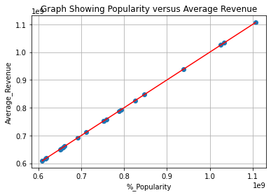

```python
x=popularity_df['%_Popularity']
y=aggregate_df['Average_Revenue']

plt.scatter(x,y)

#calculate equation for trendline
z = np.polyfit(x, y, 1)
p = np.poly1d(z)
plt.xlabel('%_Popularity')
plt.ylabel('Average_Revenue')
plt.title("Graph Showing Popularity versus Average Revenue")
plt.grid(True)
#add trendline to plot
plt.plot(x, p(x),color="red")
```

##### Observation:

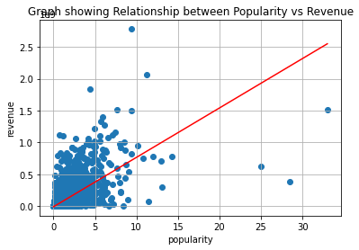

```python
#The popularity by genre and revenue by genre graphs are very similar,
#now lets look the relationship of revenue and populrity by
scatter_chart("popularity","revenue","popularity","revenue","Graph showing Relationship between Popularity vs Revenue")
```

##### Observation:

From the graph we see that the scatterplot is quite close. There seems to be a positive relationship between the variables. This shows that there is a some correlation between popularity and revenue.

### 6. What is the relationship between popularity and runtime?

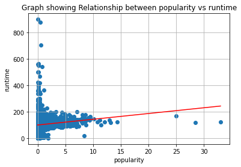

```python
scatter_chart("popularity","runtime","popularity","runtime","Graph showing Relationship between popularity vs runtime")
```

##### Observation:

From the graph we see that the scatterplot is quite close. There does not seem to be a strong correlation between runtime and popularity.

### 7. Does a larger budget lead to larger revenues?

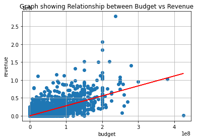

```python
scatter_chart("budget","revenue","budget","revenue","Graph showing Relationship between Budget vs Revenue")
```

### 8. What is the relationshp between votes and popularity?

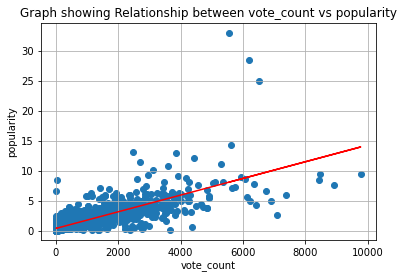

```python
scatter_chart("vote_count","popularity","vote_count","popularity","Graph showing Relationship between vote_count vs popularity")
```

##### Observation:

From the graph we see that the scatterplot is quite close. There seems to be a positive relationship between the variables. This shows that there is a some correlation between popularity and vote count.

### 9. What is the relationship between budget and runtime?

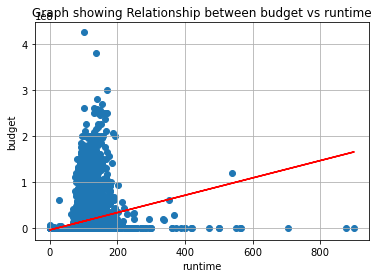

```python
scatter_chart("runtime","budget","runtime","budget","Graph showing Relationship between budget vs runtime")
```

### 10. Do all movies make profits?

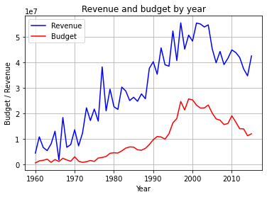

```python
#create line graph, group the movies by year and display.
year_revenue = df_movies.groupby('release_year')['revenue'].mean().plot(label="Revenue",color="blue")
year_budget = df_movies.groupby('release_year')['budget'].mean().plot(label="Budget",color="red")
plt.title("Revenue and budget by year")
plt.xlabel("Year")
plt.ylabel("Budget / Revenue")
plt.legend(loc='best')
plt.grid(True)
plt.show()
```

### 11. Which genre is the most common?

```python
genres=df_movies["genres"]
genres.head()
```

```
0    Action|Adventure|Science Fiction|Thriller
1    Action|Adventure|Science Fiction|Thriller
2           Adventure|Science Fiction|Thriller
3     Action|Adventure|Science Fiction|Fantasy
4                        Action|Crime|Thriller
Name: genres, dtype: object
```

```python
#Create a dataframe from the genres column and split it into seperate genres to count the indivdual genres
genres=df_movies['genres'].str.split('|').explode('genres')
genre_count=genres.value_counts()
genre_count
```

```
Drama              4760
Comedy             3793
Thriller           2907
Action             2384
Romance            1712
Horror             1637
Adventure          1471
Crime              1354
Family             1231
Science Fiction    1229
Fantasy             916
Mystery             810
Animation           699
Documentary         520
Music               408
History             334
War                 270
Foreign             188
TV Movie            167
Western             165
unknown              23
Name: genres, dtype: int64
```

##### Observation:

The count from the dataframe shows that Drama is the most common genre.

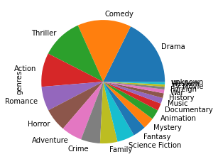

```python
#pie chart to view the genres
genre_count.plot.pie(y='genres')
```

### 12. Which Director has directed the most movies in the list?

```python
#calculate the number of films directed by each director in the database
df_director=df_movies.drop(df_movies[df_movies['director'] == "unknown"].index, inplace = True)
director_count=df_movies['director'].value_counts()
director_count.head()
```

```
Woody Allen         45
Clint Eastwood      34
Martin Scorsese     29
Steven Spielberg    29
Ridley Scott        23
Name: director, dtype: int64
```

##### Observation:

From the dataframe we see that Woody Allen has directed the most movies with a total of 45.

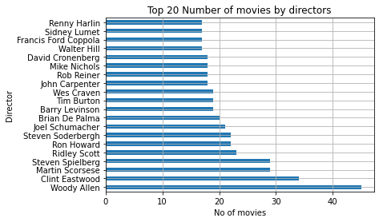

```python
director_count.head(20).plot.barh()
plt.title("Top 20 Number of movies by directors")
plt.xlabel("No of movies")
plt.ylabel("Director")
plt.grid()
```

##### Observation:

From the graph we see the top 20 directors that directed the most films. Woody Allen directed the most and Renny Harlin and Francis Ford Coppola directed the least.

### 13. Which director has the highest earning movies?

```python
#calculate the total revenue for the films directed by the director
def barh_plot(column1,column2,sort_column,drop_unknown,title,x_label,y_label):
    director_revenue = df_movies.groupby(column1)[column2].sum()
    director_revenue=pd.DataFrame(director_revenue)
    director_revenue=director_revenue.sort_values(sort_column,ascending=False)
    director_revenue.drop(director_revenue[director_revenue[drop_unknown]==0].index,inplace=True)
    director_revenue.head(20).plot.barh()
    plt.title(title)
    plt.xlabel(x_label)
    plt.ylabel(y_label)
    plt.grid()
```

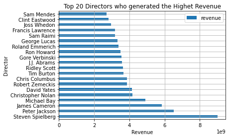

```python
barh_plot('director','revenue',"revenue","revenue","Top 20 Directors who generated the Highet Revenue","Revenue","Director")
```

##### Observation:

From the graph we see the top 20 directors with the highest revenue . Steven Speilberg has the highest revenuet and RSam Mendes the least.

### 14. Which production company produced the most movies?

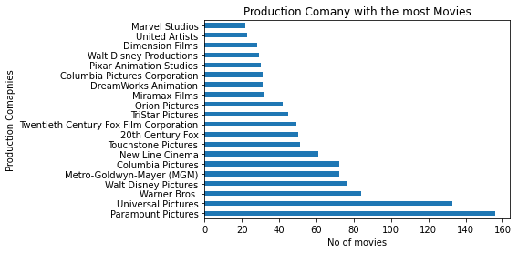

```python
#view the number of movies produced by the production companies
df_comp=df_movies.drop(df_movies[df_movies['production_companies'] == "unknown"].index, inplace = True)
company_count=df_movies['production_companies'].value_counts()
company_count.head(20).plot.barh()
plt.title("Production Comany with the most Movies")
plt.xlabel("No of movies")
plt.ylabel("Production Comapnies")
plt.grid(True)
plt.grid()
```

### 15. Which production company had the highest revenue?

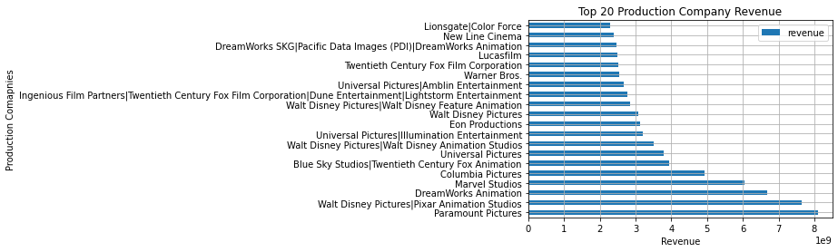

```python
#calculate the revenue of each production company
produced_movies_revenue = df_movies.groupby('production_companies')['revenue'].sum()
produced_movies_revenue=pd.DataFrame(produced_movies_revenue)
produced_movies_revenue=produced_movies_revenue.sort_values("revenue",ascending=False)
produced_movies_revenue.head(20).plot.barh()
plt.title("Top 20 Production Company Revenue")
plt.xlabel("Revenue")
plt.ylabel("Production Comapnies")
plt.grid(True)
```

##### Observation:

From the graph we see the top 20 Production companies with the most revenue. Paramount Pictures has the highest revenue and Lionsgate|Color Force earned the least.

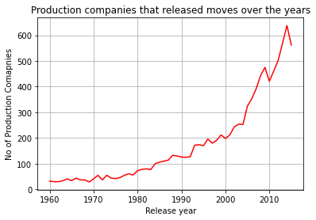

```python
prod_co_releases = df_movies.groupby('release_year')['production_companies'].count().plot(color="red")
plt.title("Production companies that released moves over the years")
plt.xlabel("Release year")
plt.ylabel("No of Production Comapnies")
plt.grid(True)
```

## Limitations

1. The dataset contained rows with missing data. This data was filed with unknown.
2. There was 1 row of duplicated data that had to be removed.
3. There were a large number of unknwon production comapnies, this may limit the accuracy of which production company produced the most movies and which company had the highest revenue. The unknowns had to be removed.